# **Cluster Analysis Of Education Data In Karnataka**

Author: Mrinalini Kabbur Date: November 2, 2017

### **Introduction**

Primary school Enrolment in India has seen a big increase from 79% in 2000 and to 93% in 2014. Type of schooling also has changed. Percentage of kids going to private schools has almost doubled in the last 15 years to 35% in 2014. This in spite of the fact that the private schools cost four to five times more. The general notion is that private schools offer better quality of education. The primary school dropout rate is 4.34% in 2014, which is at the lowest ever. RTE Act passed in 2009 took a big step in improving the educational inputs. It declared public primary education a human right for all the children in the age group 6-14. It Established standards for school infrastructure, learning materials, teacher qualifications and student admission and also instituted private school quotas for disadvantaged children. The expenditure on education increased manifold through Sarva Shikshana Abhiyana (SSA) funds. SSA components include School maintenance grant (SMG) for school facilities, School Development grant (SDG) for day to day operation and administration and Teaching and learning material grant (TLM) to purchase teaching aid other than the textbooks.  
This study looks at how RTE guidelines along with private schooling and decrease in out of school children have impacted the ultimate goal of learning outcomes in primary school education. Along with the above listed inputs, socio-economic factors like literacy rate, caste distribution of enrolled children and teachers, Gender distribution of children and teachers as well as medium of instruction as in English or mother tongue are also considered.

### **Data and Methodology**

This study uses three sources of Data. The first is the District Information System for Education (DISE). This database is developed by National University for Educational Planning and Administration (NUEPA) and records information about all the schools in India. The information collected includes Household characterisitcs such as socio-economic status, school infrastructure, Teacher and Children Characteristics such as age gender, caste, religion etc. The second source is ASER that stands for Annual Status of Education Report. This is an annual survey that aims to provide reliable estimates of children’s enrolment and basic learning levels for each district and state in India. Thirdly, RTE compliance score is pulled from socialcops.com website. Here the RTE values from the DISE database are extracted and an aggregated score is computed that assesses the level of RTE implementation in each district. The data from all the sources is gathered for the year 2013-14. The study uses primary school data for 26 districts of Karnataka. Districts of Ramanagar, Yadgiri, Chikkaballapur and Bangalore Urban are excluded as ASER survey did not collect learning outcomes for these districts.  
For the study, we use cluster analysis, a data mining technique based on unsupervised learning. Unsupervised learning explores ‘unlabelled’ or ‘unclassified’ data to find hidden patterns. There is no target attribute here. Cluster analysis groups subjects that depict similar characteristics.Agglomerative hierarchical clustering technique is chosen here as the number of observations are less. Among various agglomerative procedures, Wards’s method is used. This method merges objects that increases the within cluster variance to the lowest possible degree.  
The study performs cluster analysis on 16 parameters gathered from the three data sources mentioned above. We group districts that are similar in terms of characteristics.Also, among the different variables used for analysis, more weightage is given to the 2 learning outcome parameters. The reason being that we want the districts to be distinguishable based on their performance.  
The cluster analysis is performed using R programming language, an open source software for statistical computations and graphics. Agglomerative Hierarchical cluster analysis is provided in R through the hclust function.

### **Data Exploration**

District is the unit of analysis here. The data exploration is done using box plots and summary function. The ASER survey 2014 did not collect learning outcome data for the newly formed districts of Ramanagar, Chikkaballapur and Yadgiri. Hence, they are integrated with their previous districts.  
The boxplots detected outliers for the variables, girl boy ratio, gender distribution of teachers, Not in School children, Private School Enrolment and reading level. Upon further inspection, the values are found to be appropriate and no outlier treatment is applied.

### **Data Preparation**

In order to do an effective clustering, we need to adjust the variables to a common scale. This is called ‘scaling’. Among the variables used for this study, all the values are percentages except girl boy ratio, gender distribution of teachers and RTE compliance score. Common scaling can be achieved by converting these values to percentages as well. However, we use scale function that standardizes all the values to z-scores. Next step is ‘Weighting’. Since we want the clusters to be distinguishable based on their performance, we add more weightage to the corresponding values. We augment the outcome values by three times.

### **Build Model**

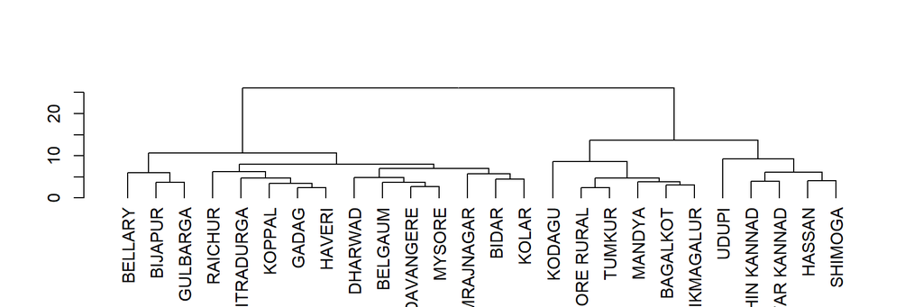

We can see from the figure that the best choices for total number of clusters are either 2 or 3:

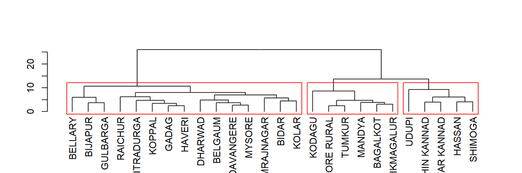

To do this, we can cut off the tree at the desired number of clusters using cutree function

### **Profiling**

The cluster analysis resulted in 3 clusters. They can be categorised as ‘Good’, ‘Average’ and ‘Poor’ in terms of learning outcomes.

Table 1: Clustering Of Districts In Terms Of Learning Outcomes

| Learning Outcome | Count | Districts |
| --- | --- | --- |
| Good Performing | 5 | Dakshina Kannada, Uttara Kannada, Udupi, Shimoga and Hassan |
| Average Performing | 6 | Bagalkot, Bangalore Rural, Chikmangaluru, Kodagu, Tumkur and Mandya |
| Poor Performing | 15 | Belgaum, Bidar, Bijapur, Bellary, Chamarajnagar, Chitradurga, Davangere, Dharwad, Gadag, Gulbarga, Haveri, Kolar, Koppal, Mysore, Raichur |

A thematic map of Karnataka showing learning outcomes is constructed using sp, rgdal, raster and tmap packages.

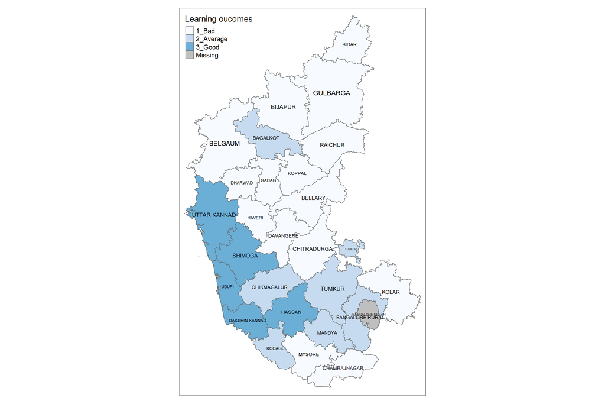

Table 2: Cluster Averages and Total Average Of Each Characteristic

[output not shown]